# Yukon River Fall Chum Salmon Inseason Mixed Stock Analysis

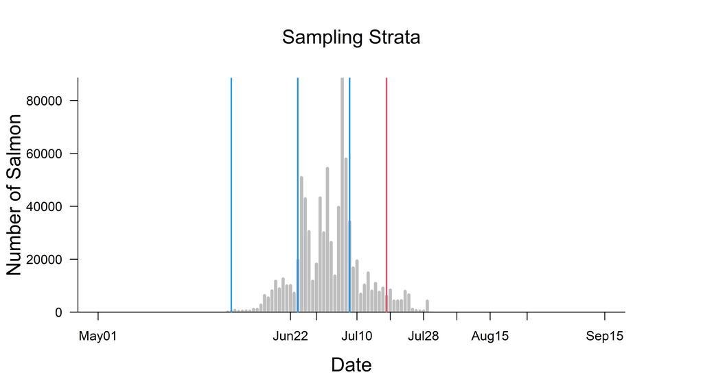

Figure 1. Daily sonar counts attributed to chum salmon (bars) showing genetic sampling time frames (droplines), project operated near Pilot Station, Yukon Area, 2024.

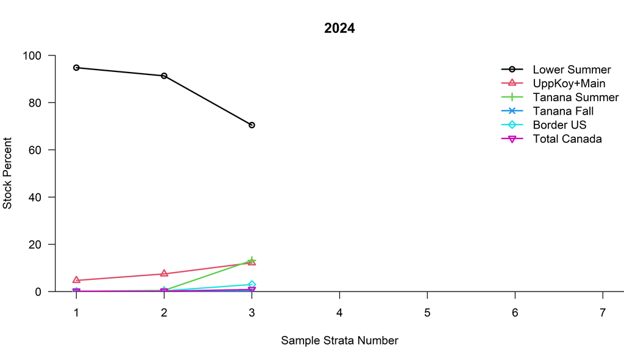

Figure 2. Mean proportion of chum salmon stock groups by sampling strata, Yukon Area, 2024.

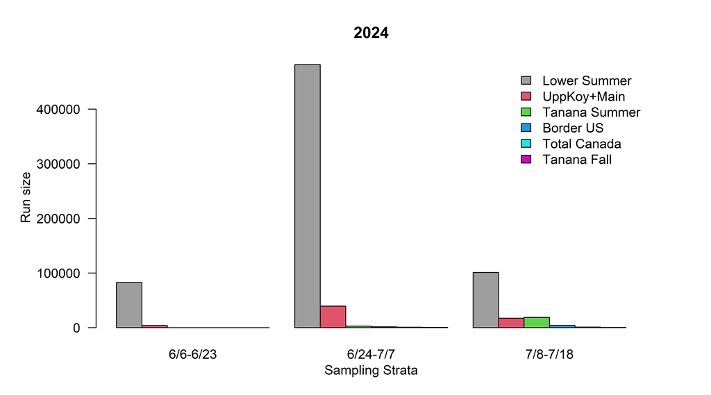

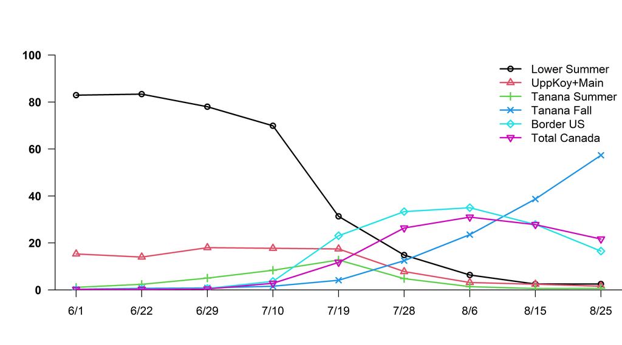

Figure 3. Mean proportion of chum salmon stock groups by standard sampling strata, Yukon Area, 2004-2023.

[figure not shown]

Figure 4. Minimum and maximum (2004-2023) and 2024 mean stock proportion by standard sampling strata, comparing the major chum salmon components, Yukon Area.

[figure not shown]

Figure 5. Crossover of summer and fall chum salmon based on genetic stock analysis (standard sampling strata), Yukon Area, 1999-2002 using allozymes and 2004-2024 using microsatellites.

[figure not shown]

Figure 6. Crossover of summer and fall chum salmon (3 periods) based on genetic stock analysis (standard sampling strata), Yukon Area, 1999-2002 using allozymes and 2004-2024 using microsatellites.